# R Notebook

**First, check about the distribution of the crime variables**

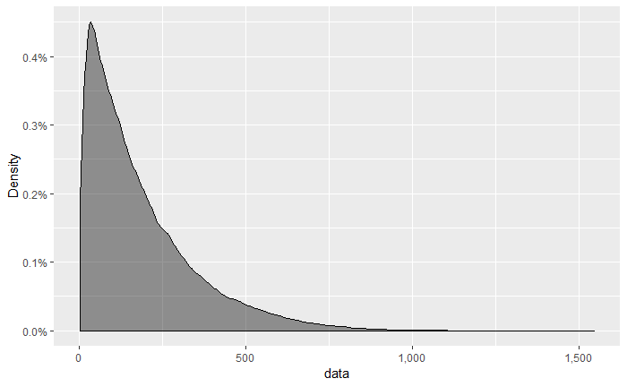

```r
plot_density(df$CRMCYPERC)
```

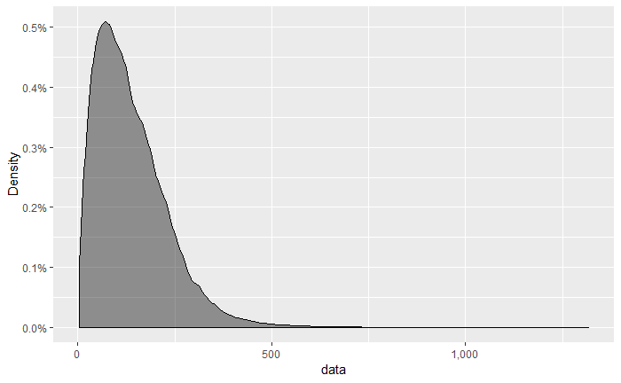

```r
plot_density(df$CRMCYPROC)
```

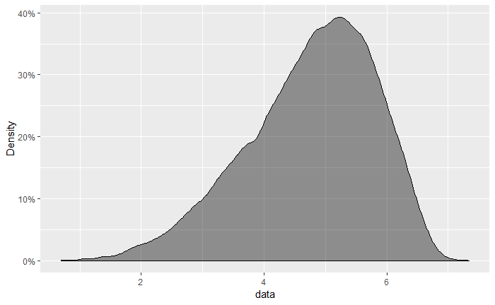

```r
plot_density(log(df$CRMCYPERC))
```

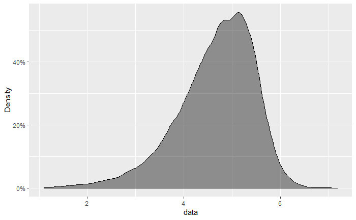

```r
plot_density(log(df$CRMCYPROC))
```

For the 2 crime variables, log transforming looks much more normally distributed. 2 options then, transform the response variable or use a GLMM. If specifying a distribution could use a poisson to account for the heavy skew (perhaps).

If transforming, then a 1 unit increase in the explanatory variable equals a *x* log unit change in the response (or the expected log count for a one-unit increase in X). Sometimes this can also be stated as a % change in the response.

**Try lm vs. glm first**

```r
mod_01 <- lm(CRMCYPERC ~ ndvi_mean_cbg_adj + MedHHinc_000 + divindex + disad + log_popden_cbg , data = df)
mod_02 <- glm(CRMCYPERC ~ ndvi_mean_cbg_adj + MedHHinc_000 + divindex + disad + log_popden_cbg , data = df, family = 'poisson')
summary(mod_01)
```

```
Call:
lm(formula = CRMCYPERC ~ ndvi_mean_cbg_adj + MedHHinc_000 + divindex +
    disad + log_popden_cbg, data = df)

Residuals:
    Min      1Q  Median      3Q     Max
-437.37  -77.53  -23.32   53.89 1079.36

Coefficients:
                   Estimate Std. Error t value Pr(>|t|)
(Intercept)       321.23214    5.48920  58.521   <2e-16 ***
ndvi_mean_cbg_adj   0.22904    0.40069   0.572    0.568
MedHHinc_000       -0.50534    0.02183 -23.150   <2e-16 ***
divindex          -58.92475    2.92589 -20.139   <2e-16 ***
disad             117.53070    0.92409 127.185   <2e-16 ***
log_popden_cbg    -12.57129    0.53602 -23.453   <2e-16 ***
---
Signif. codes:  0 ‘***’ 0.001 ‘**’ 0.01 ‘*’ 0.05 ‘.’ 0.1 ‘ ’ 1

Residual standard error: 125.2 on 59641 degrees of freedom
  (2439 observations deleted due to missingness)
Multiple R-squared:  0.3995,    Adjusted R-squared:  0.3995
F-statistic:  7937 on 5 and 59641 DF,  p-value: < 2.2e-16
```

```r
summary(mod_02)
```

```
Call:
glm(formula = CRMCYPERC ~ ndvi_mean_cbg_adj + MedHHinc_000 +
    divindex + disad + log_popden_cbg, family = "poisson", data = df)

Deviance Residuals:
    Min       1Q   Median       3Q      Max
-32.499   -7.228   -2.337    3.914   58.073

Coefficients:
                    Estimate Std. Error z value Pr(>|z|)
(Intercept)        6.070e+00  3.255e-03 1864.95   <2e-16 ***
ndvi_mean_cbg_adj -6.363e-03  2.385e-04  -26.68   <2e-16 ***
MedHHinc_000      -9.452e-03  1.831e-05 -516.32   <2e-16 ***
divindex          -1.386e-01  1.654e-03  -83.80   <2e-16 ***
disad              3.983e-01  5.037e-04  790.79   <2e-16 ***
log_popden_cbg    -5.729e-02  3.158e-04 -181.40   <2e-16 ***
---
Signif. codes:  0 ‘***’ 0.001 ‘**’ 0.01 ‘*’ 0.05 ‘.’ 0.1 ‘ ’ 1

(Dispersion parameter for poisson family taken to be 1)

    Null deviance: 7694756  on 59646  degrees of freedom
Residual deviance: 4440544  on 59641  degrees of freedom
  (2439 observations deleted due to missingness)
AIC: 4833219

Number of Fisher Scoring iterations: 5
```

```r
exp(coef(mod_02))
```

```
      (Intercept) ndvi_mean_cbg_adj      MedHHinc_000          divindex             disad
      432.7051706         0.9936574         0.9905930         0.8705485         1.4893237
   log_popden_cbg
        0.9443202
```

So a glm or glmm might be better, maybe :)

**Look at the variables going into the model**

There is a warning that variables are on different scales, look into this.

```r
summary(df[, c(13, 18, 44:67)])
```

```
   CRMCYPERC        CRMCYPROC      gndctr_ndvi_cbg_adj gndctr_MedHHinc000  gndctr_disad
 Min.   :   2.0   Min.   :   3.0   Min.   :-3.55007    Min.   :-53.168    Min.   :-1.2700
 1st Qu.:  60.0   1st Qu.:  67.0   1st Qu.:-1.30891    1st Qu.:-23.499    1st Qu.:-0.6359
 Median : 134.0   Median : 118.0   Median : 0.08054    Median : -7.517    Median :-0.1529
 Mean   : 183.2   Mean   : 137.1   Mean   : 0.00000    Mean   :  0.000    Mean   : 0.0000
 3rd Qu.: 258.0   3rd Qu.: 188.0   3rd Qu.: 1.23966    3rd Qu.: 15.155    3rd Qu.: 0.5104
 Max.   :1548.0   Max.   :1318.0   Max.   : 3.99548    Max.   :194.334    Max.   : 4.0619
                                                       NA's   :2383       NA's   :504
  gndctr_diver        gndctr_U18      gndctr_logpopden       gpc_ndvi       gpc_medhh
 Min.   :-0.35976   Min.   :-22.188   Min.   :-10.18814   Min.   :1.435   Min.   : 28.02
 1st Qu.:-0.14677   1st Qu.: -6.479   1st Qu.: -0.64217   1st Qu.:2.751   1st Qu.: 45.37
 Median : 0.02591   Median :  0.080   Median : -0.04115   Median :4.266   Median : 54.17
 Mean   : 0.00000   Mean   :  0.000   Mean   :  0.00000   Mean   :4.064   Mean   : 55.55
 3rd Qu.: 0.14931   3rd Qu.:  6.518   3rd Qu.:  0.66488   3rd Qu.:5.119   3rd Qu.: 62.05
 Max.   : 0.30689   Max.   : 66.903   Max.   :  4.42016   Max.   :6.483   Max.   :119.65
 NA's   :212        NA's   :212
   gpc_disad          gpc_diver         gpc_U18        gpc_logpop    grpctr_ndvi_cbg_adj
 Min.   :-0.79917   Min.   :0.1021   Min.   :11.92   Min.   :6.216   Min.   :-4.317449
 1st Qu.:-0.14766   1st Qu.:0.3053   1st Qu.:20.62   1st Qu.:7.310   1st Qu.:-0.483838
 Median : 0.11119   Median :0.3683   Median :22.04   Median :7.646   Median : 0.007979
 Mean   : 0.07146   Mean   :0.3598   Mean   :22.19   Mean   :7.886   Mean   : 0.000000
 3rd Qu.: 0.22550   3rd Qu.:0.4013   3rd Qu.:24.16   3rd Qu.:8.387   3rd Qu.: 0.498145
 Max.   : 1.21854   Max.   :0.5838   Max.   :32.58   Max.   :9.671   Max.   : 4.799172

 grpctr_MedHHinc000  grpctr_disad      grpctr_diver      grpctr_PcU18whole   grpctr_log_popden_cbg
 Min.   :-90.20     Min.   :-2.0600   Min.   :-0.55174   Min.   :-31.42994   Min.   :-11.9731
 1st Qu.:-19.23     1st Qu.:-0.5151   1st Qu.:-0.11898   1st Qu.: -6.08358   1st Qu.: -0.3428
 Median : -5.28     Median :-0.0959   Median : 0.01602   Median :  0.07321   Median :  0.1278
 Mean   :  0.00     Mean   : 0.0000   Mean   : 0.00000   Mean   :  0.00000   Mean   :  0.0000
 3rd Qu.: 13.12     3rd Qu.: 0.4409   3rd Qu.: 0.12206   3rd Qu.:  6.02161   3rd Qu.:  0.5296
 Max.   :202.21     Max.   : 3.9898   Max.   : 0.48511   Max.   : 67.94366   Max.   :  3.5379
 NA's   :2383       NA's   :504       NA's   :212        NA's   :212
 gndctr_MetroGDP   gndctr_Police     gndctr_rt_total    gndctr_rt_violent gndctr_rt_property
 Min.   :-411799   Min.   :-2.4630   Min.   :-29.2822   Min.   :-6.4397   Min.   :-24.48490
 1st Qu.:-347177   1st Qu.:-0.9673   1st Qu.:-13.6630   1st Qu.:-2.5426   1st Qu.:-10.85981
 Median :-225530   Median :-0.4346   Median : -0.3141   Median :-0.9585   Median : -0.03537
 Mean   :      0   Mean   : 0.0000   Mean   :  0.0000   Mean   : 0.0000   Mean   :  0.00000
 3rd Qu.:  80215   3rd Qu.: 0.6981   3rd Qu.: 12.2591   3rd Qu.: 2.0934   3rd Qu.:  9.50786
 Max.   :1191852   Max.   : 3.3117   Max.   : 60.4757   Max.   :11.2262   Max.   : 58.86831

    PCgdp15
 Min.   : 20463
 1st Qu.: 45092
 Median : 57746
 Mean   : 56643
 3rd Qu.: 65309
 Max.   :178314
```

** Subset data and create standardized variables **

```r
std_df <- model_df %>% mutate_if(is.numeric, funs(scale(.) %>% as.vector)) %>% left_join(df_na[, c(1, 3)])
```

#### Models

The multilevel model with level 1 and 2 covariates plus interaction.

```r
mod_03 <- lmer(CRMCYPERC ~ gndctr_ndvi_cbg_adj*clustname + gndctr_MedHHinc000 + gndctr_disad + gndctr_diver + gndctr_U18 + gndctr_logpopden + gndctr_Police + gndctr_PCgdp15 + gndctr_rt_violent + (gndctr_ndvi_cbg_adj|city_st), data = model_df)
```

```
Some predictor variables are on very different scales: consider rescaling
```

```r
mod_04 <- lmer(CRMCYPERC ~ gndctr_ndvi_cbg_adj*clustname + gndctr_MedHHinc000 + gndctr_disad + gndctr_diver + gndctr_logpopden + gndctr_PCgdp15 + gndctr_rt_violent + (gndctr_ndvi_cbg_adj|city_st), data = model_df)
```

```
Some predictor variables are on very different scales: consider rescaling
```

```r
screenreg(list(mod_03, mod_04))
```

```
============================================================================
                                              Model 1         Model 2
----------------------------------------------------------------------------
(Intercept)                                       172.83 ***      169.86 ***
                                                   (7.05)          (6.17)
gndctr_ndvi_cbg_adj                               -25.49 ***      -25.24 ***
                                                   (3.47)          (3.47)
clustnamecool-wet-lo                               52.81 ***       54.62 ***
                                                   (8.20)          (7.79)
clustnamewarm-dry-hi                              -22.58 *        -22.31 *
                                                   (9.93)          (9.83)
clustnamewarm-wet-hi                               25.22 **        27.25 **
                                                   (8.86)          (8.44)
gndctr_MedHHinc000                                 -0.39 ***       -0.39 ***
                                                   (0.02)          (0.02)
gndctr_disad                                       99.85 ***      100.23 ***
                                                   (0.85)          (0.78)
gndctr_diver                                      -34.87 ***      -34.63 ***
                                                   (2.61)          (2.59)
gndctr_U18                                          0.05
                                                   (0.05)
gndctr_logpopden                                  -29.98 ***      -29.92 ***
                                                   (0.57)          (0.57)
gndctr_Police                                       3.65
                                                   (3.55)
gndctr_PCgdp15                                      0.00 ***        0.00 ***
                                                   (0.00)          (0.00)
gndctr_rt_violent                                  15.41 ***       15.96 ***
                                                   (0.81)          (0.67)
gndctr_ndvi_cbg_adj:clustnamecool-wet-lo          -11.17 **       -11.30 **
                                                   (4.29)          (4.29)
gndctr_ndvi_cbg_adj:clustnamewarm-dry-hi           13.01 *         12.94 *
                                                   (5.40)          (5.40)
gndctr_ndvi_cbg_adj:clustnamewarm-wet-hi           -1.94           -1.97
                                                   (4.72)          (4.73)
----------------------------------------------------------------------------
AIC                                            717099.73       717097.99
BIC                                            717279.66       717259.92
Log Likelihood                                -358529.87      -358530.99
Num. obs.                                       59647           59647
Num. groups: city_st                              301             301
Var: city_st (Intercept)                         2161.43         2104.06
Var: city_st gndctr_ndvi_cbg_adj                  575.58          577.27
Cov: city_st (Intercept) gndctr_ndvi_cbg_adj     -704.04         -679.74
Var: Residual                                    9515.05         9515.15
============================================================================
*** p < 0.001, ** p < 0.01, * p < 0.05
```

```r
anova(mod_04, mod_03)
```

```
refitting model(s) with ML (instead of REML)
```

```
Data: model_df
Models:
mod_04: CRMCYPERC ~ gndctr_ndvi_cbg_adj * clustname + gndctr_MedHHinc000 +
mod_04:     gndctr_disad + gndctr_diver + gndctr_logpopden + gndctr_PCgdp15 +
mod_04:     gndctr_rt_violent + (gndctr_ndvi_cbg_adj | city_st)
mod_03: CRMCYPERC ~ gndctr_ndvi_cbg_adj * clustname + gndctr_MedHHinc000 +
mod_03:     gndctr_disad + gndctr_diver + gndctr_U18 + gndctr_logpopden +
mod_03:     gndctr_Police + gndctr_PCgdp15 + gndctr_rt_violent + (gndctr_ndvi_cbg_adj |
mod_03:     city_st)
       Df    AIC    BIC  logLik deviance  Chisq Chi Df Pr(>Chisq)
mod_04 18 717120 717281 -358542   717084
mod_03 20 717121 717301 -358541   717081 2.0822      2     0.3531
```

Now try it with the standardized variables.

```r
mod_05 <- lmer(CRMCYPERC ~ gndctr_ndvi_cbg_adj*clustname + gndctr_MedHHinc000 + gndctr_disad + gndctr_diver + gndctr_U18 + gndctr_logpopden + gndctr_Police + gndctr_PCgdp15 + gndctr_rt_violent + (gndctr_ndvi_cbg_adj|city_st), data = std_df)
mod_06 <- lmer(CRMCYPERC ~ gndctr_ndvi_cbg_adj*clustname + gndctr_MedHHinc000 + gndctr_disad + gndctr_diver + gndctr_logpopden + gndctr_PCgdp15 + gndctr_rt_violent + (gndctr_ndvi_cbg_adj|city_st), data = std_df)
screenreg(list(mod_05, mod_06))
```

```
==========================================================================
                                              Model 1        Model 2
--------------------------------------------------------------------------
(Intercept)                                       -0.06          -0.08 *
                                                  (0.04)         (0.04)
gndctr_ndvi_cbg_adj                               -0.24 ***      -0.24 ***
                                                  (0.03)         (0.03)
clustnamecool-wet-lo                               0.33 ***       0.34 ***
                                                  (0.05)         (0.05)
clustnamewarm-dry-hi                              -0.14 *        -0.14 *
                                                  (0.06)         (0.06)
clustnamewarm-wet-hi                               0.16 **        0.17 **
                                                  (0.05)         (0.05)
gndctr_MedHHinc000                                -0.08 ***      -0.08 ***
                                                  (0.00)         (0.00)
gndctr_disad                                       0.49 ***       0.49 ***
                                                  (0.00)         (0.00)
gndctr_diver                                      -0.04 ***      -0.04 ***
                                                  (0.00)         (0.00)
gndctr_U18                                         0.00
                                                  (0.00)
gndctr_logpopden                                  -0.21 ***      -0.21 ***
                                                  (0.00)         (0.00)
gndctr_Police                                      0.03
                                                  (0.03)
gndctr_PCgdp15                                     0.06 ***       0.06 ***
                                                  (0.02)         (0.01)
gndctr_rt_violent                                  0.36 ***       0.37 ***
                                                  (0.02)         (0.02)
gndctr_ndvi_cbg_adj:clustnamecool-wet-lo          -0.10 **       -0.11 **
                                                  (0.04)         (0.04)
gndctr_ndvi_cbg_adj:clustnamewarm-dry-hi           0.12 *         0.12 *
                                                  (0.05)         (0.05)
gndctr_ndvi_cbg_adj:clustnamewarm-wet-hi          -0.02          -0.02
                                                  (0.04)         (0.04)
--------------------------------------------------------------------------
AIC                                           110653.51      110636.62
BIC                                           110833.43      110798.55
Log Likelihood                                -55306.76      -55300.31
Num. obs.                                      59647          59647
Num. groups: city_st                             301            301
Var: city_st (Intercept)                           0.08           0.08
Var: city_st gndctr_ndvi_cbg_adj                   0.05           0.05
Cov: city_st (Intercept) gndctr_ndvi_cbg_adj      -0.04          -0.04
Var: Residual                                      0.36           0.36
==========================================================================
*** p < 0.001, ** p < 0.01, * p < 0.05
```

```r
anova(mod_06, mod_05)
```

```
refitting model(s) with ML (instead of REML)
```

```
Data: std_df
Models:
mod_06: CRMCYPERC ~ gndctr_ndvi_cbg_adj * clustname + gndctr_MedHHinc000 +
mod_06:     gndctr_disad + gndctr_diver + gndctr_logpopden + gndctr_PCgdp15 +
mod_06:     gndctr_rt_violent + (gndctr_ndvi_cbg_adj | city_st)
mod_05: CRMCYPERC ~ gndctr_ndvi_cbg_adj * clustname + gndctr_MedHHinc000 +
mod_05:     gndctr_disad + gndctr_diver + gndctr_U18 + gndctr_logpopden +
mod_05:     gndctr_Police + gndctr_PCgdp15 + gndctr_rt_violent + (gndctr_ndvi_cbg_adj |
mod_05:     city_st)
       Df    AIC    BIC logLik deviance  Chisq Chi Df Pr(>Chisq)
mod_06 18 110544 110706 -55254   110508
mod_05 20 110546 110726 -55253   110506 2.0822      2     0.3531
```

Look at an interaction plot for mod_04

```
Some predictor variables are on very different scales: consider rescaling
```

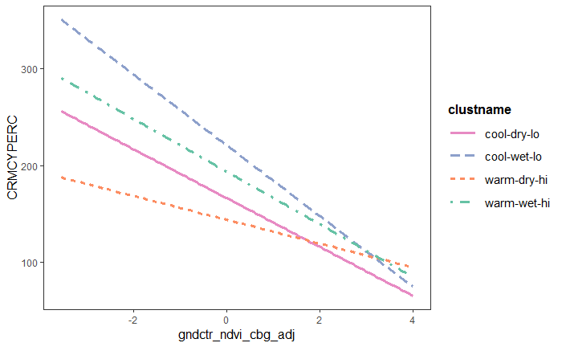

```r
interact_plot(mod_04, pred = gndctr_ndvi_cbg_adj, modx = clustname)
```

and with the same variables but standardized…

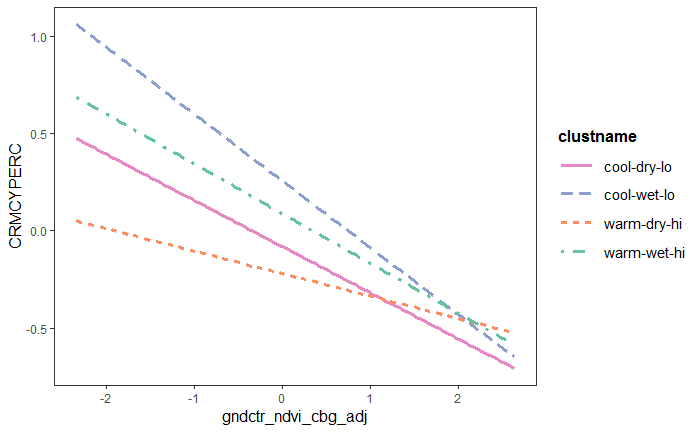

#### GLMM

https://biol609.github.io/lectures/04_gls.html#/section  
https://stats.idre.ucla.edu/r/dae/poisson-regression/

```r
mod_07 <- glmer(CRMCYPERC ~ gndctr_ndvi_cbg_adj*clustname + gndctr_MedHHinc000 + gndctr_disad + gndctr_diver + gndctr_logpopden + gndctr_PCgdp15 + gndctr_rt_violent + (gndctr_ndvi_cbg_adj|city_st), data = std_df, family = "poisson")
```

```
Error in eval(family$initialize, rho) :
  negative values not allowed for the 'Poisson' family
```